# Exploratory Data Analysis by Rob Hickey

The dataset I am using has 1599 instances of bottles of red wine and a number variables that capture characteristics of those wines (11) and one variable that captures the quality of the wine on a scale of 1-10 as measured as the median of at least 3 evaluations made by wine experts.

# Univariate Plots Section

```
##        X          fixed.acidity   volatile.acidity  citric.acid
##  Min.   :   1.0   Min.   : 4.60   Min.   :0.1200   Min.   :0.000
##  1st Qu.: 400.5   1st Qu.: 7.10   1st Qu.:0.3900   1st Qu.:0.090
##  Median : 800.0   Median : 7.90   Median :0.5200   Median :0.260
##  Mean   : 800.0   Mean   : 8.32   Mean   :0.5278   Mean   :0.271
##  3rd Qu.:1199.5   3rd Qu.: 9.20   3rd Qu.:0.6400   3rd Qu.:0.420
##  Max.   :1599.0   Max.   :15.90   Max.   :1.5800   Max.   :1.000
##  residual.sugar     chlorides       free.sulfur.dioxide
##  Min.   : 0.900   Min.   :0.01200   Min.   : 1.00
##  1st Qu.: 1.900   1st Qu.:0.07000   1st Qu.: 7.00
##  Median : 2.200   Median :0.07900   Median :14.00
##  Mean   : 2.539   Mean   :0.08747   Mean   :15.87
##  3rd Qu.: 2.600   3rd Qu.:0.09000   3rd Qu.:21.00
##  Max.   :15.500   Max.   :0.61100   Max.   :72.00
##  total.sulfur.dioxide    density             pH          sulphates
##  Min.   :  6.00       Min.   :0.9901   Min.   :2.740   Min.   :0.3300
##  1st Qu.: 22.00       1st Qu.:0.9956   1st Qu.:3.210   1st Qu.:0.5500
##  Median : 38.00       Median :0.9968   Median :3.310   Median :0.6200
##  Mean   : 46.47       Mean   :0.9967   Mean   :3.311   Mean   :0.6581
##  3rd Qu.: 62.00       3rd Qu.:0.9978   3rd Qu.:3.400   3rd Qu.:0.7300
##  Max.   :289.00       Max.   :1.0037   Max.   :4.010   Max.   :2.0000
##     alcohol         quality
##  Min.   : 8.40   Min.   :3.000
##  1st Qu.: 9.50   1st Qu.:5.000
##  Median :10.20   Median :6.000
##  Mean   :10.42   Mean   :5.636
##  3rd Qu.:11.10   3rd Qu.:6.000
##  Max.   :14.90   Max.   :8.000
```

I wanted to see all of the varaibles of my data set and see the interquartile ranges for later use.

#### pH Plot of Data Set

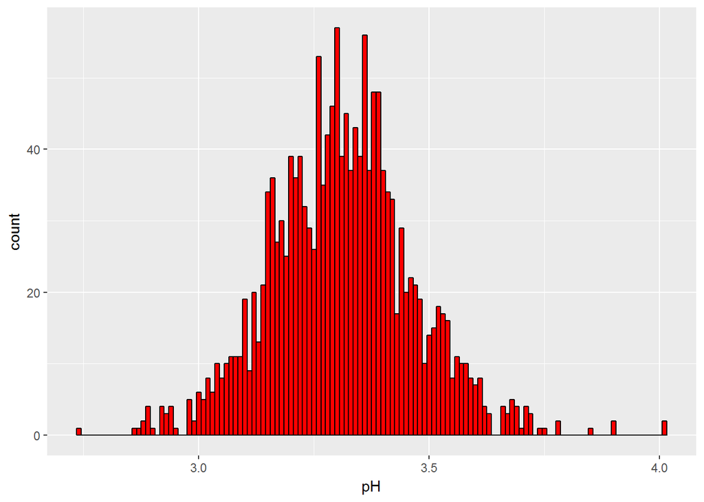

```
##    Min. 1st Qu.  Median    Mean 3rd Qu.    Max.
##   2.740   3.210   3.310   3.311   3.400   4.010
```

I was interested in getting a sense of the shape of the varaible in the data for pH. Comparing the mean value of pH for the wines in this data set to the average pH of red wines I found doing a Google search (between 3.3 and 3.6), the mean pH of the wines in our data set appears consistent with that of red wines in general.

#### Residual Sugar Plot of Data Set

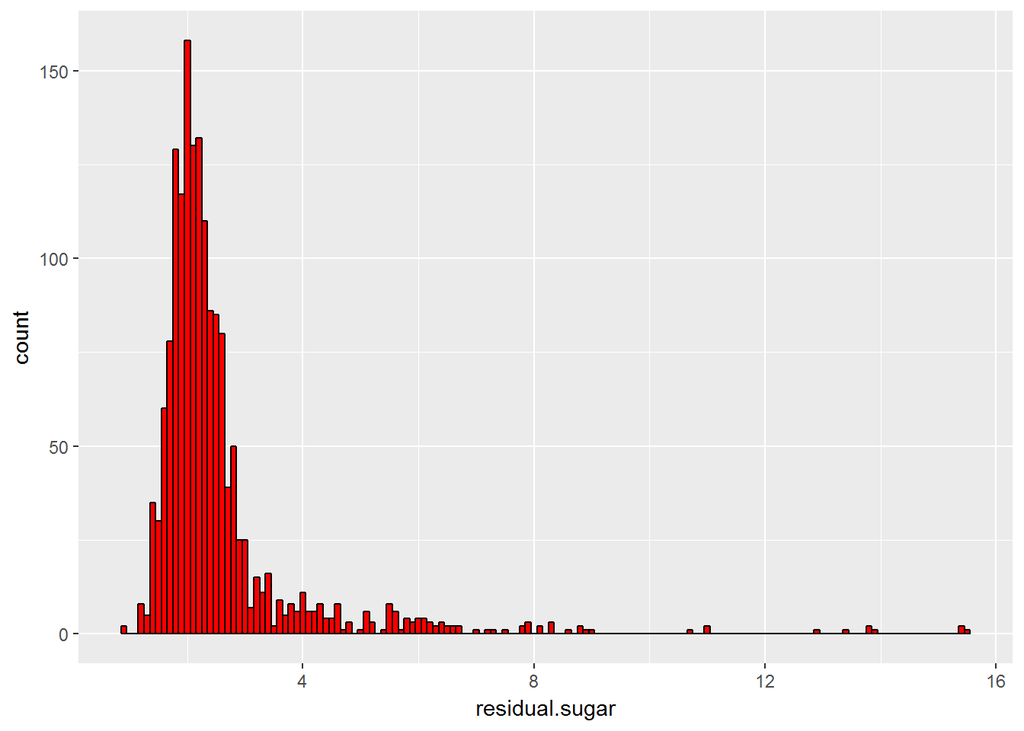

```
##    Min. 1st Qu.  Median    Mean 3rd Qu.    Max.
##   0.900   1.900   2.200   2.539   2.600  15.500
```

I was interested in getting a sense of the shape of the varaible in the data for residual sugar. Later in the analysis I wanted to see how the amount of residual sugar in the wines affected the quality scores for the wines. I suspected that a certain range of sweetness (not too sweet but sweet enough) in wines would tend to have higher scores.

#### Chloride Plot of Data Set

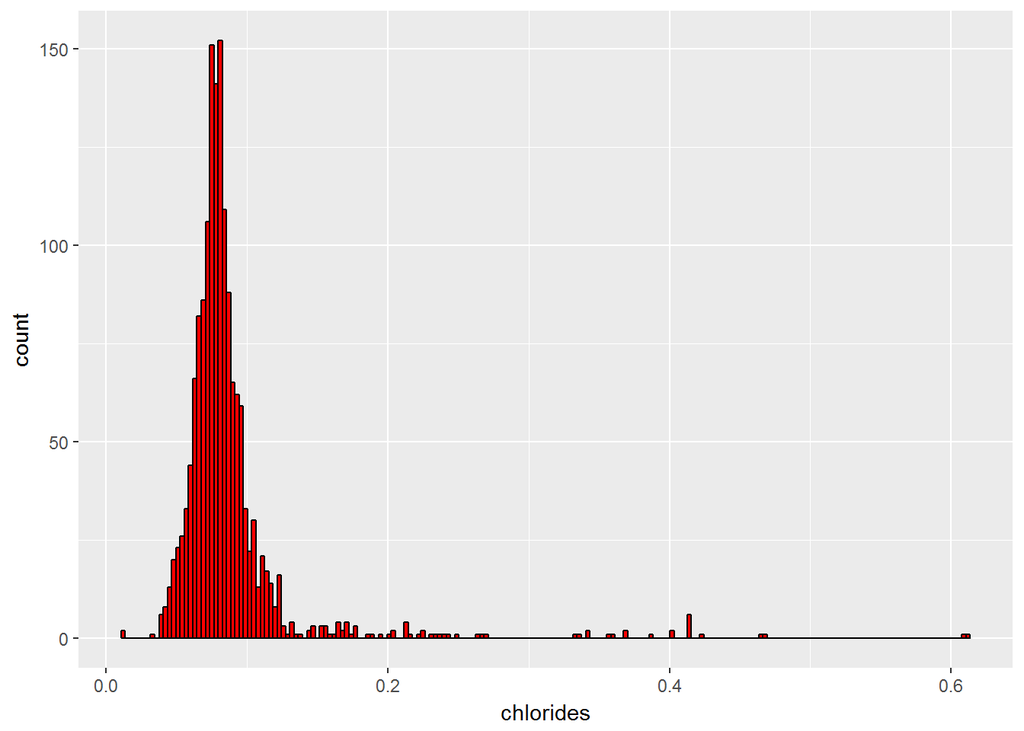

```
##    Min. 1st Qu.  Median    Mean 3rd Qu.    Max.
## 0.01200 0.07000 0.07900 0.08747 0.09000 0.61100
```

I was interested in getting a sense of the shape of the varaible in the data for salts. Later in the analysis I wanted to see how the amount of salts in the wines affected the quality scores for the wines. I suspected that a certain range of saltiness (not too salty but salty enough) in wines would tend to have higher scores.

#### Alcohol Plot of Data Set

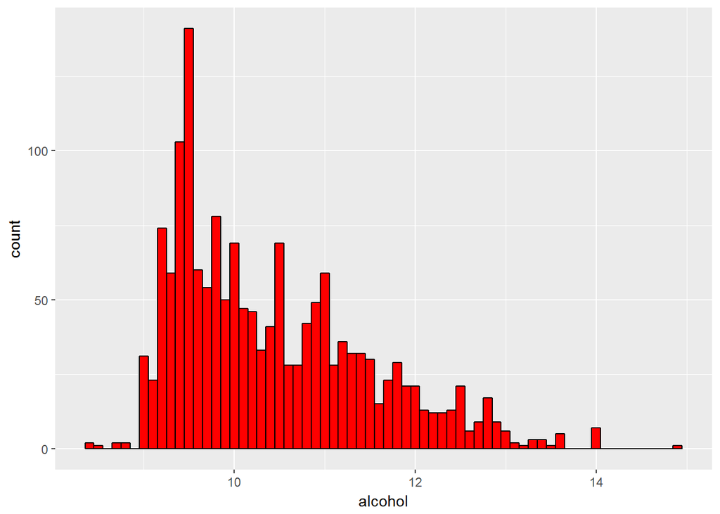

```
##    Min. 1st Qu.  Median    Mean 3rd Qu.    Max.
##    8.40    9.50   10.20   10.42   11.10   14.90
```

I was interested in getting a sense of the shape of the varaible in the data for alcohol. Later in the analysis I wanted to see how the amount of alcohol in the wines affected the quality scores for the wines. I suspected that a certain range of alcohol (not too much but not too little) in wines would tend to have higher scores.

#### Quality Plot of Data Set

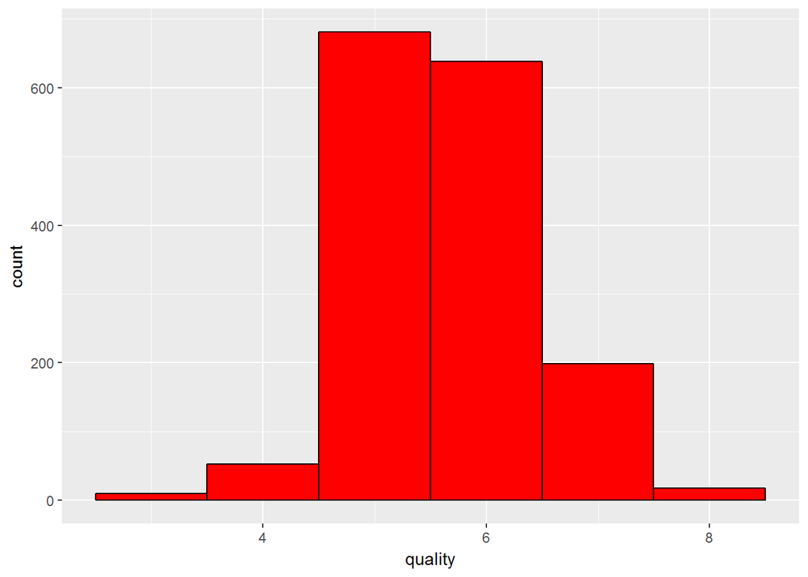

```
##    Min. 1st Qu.  Median    Mean 3rd Qu.    Max.
##   3.000   5.000   6.000   5.636   6.000   8.000
```

# Subsetting the Data

#### Looking at the Fourth and First Quartiles of the pH Data

```
##    Min. 1st Qu.  Median    Mean 3rd Qu.    Max.
##   3.000   5.000   6.000   5.563   6.000   8.000
```

```
## [1] 387
```

```
##    Min. 1st Qu.  Median    Mean 3rd Qu.    Max.
##   3.000   5.000   6.000   5.665   6.000   8.000
```

```
## [1] 388
```

It appears at first glance that high and low levels of acidity tend to receive similar quality scores. We chose the first and third quartiles as figures here so we would have approximately the same sample size.

#### Looking at the Fourth and First Quartiles of the Residual Sugar Data

```
##    Min. 1st Qu.  Median    Mean 3rd Qu.    Max.
##   3.000   5.000   6.000   5.648   6.000   8.000
```

```
## [1] 355
```

```
##    Min. 1st Qu.  Median    Mean 3rd Qu.    Max.
##   3.000   5.000   6.000   5.611   6.000   8.000
```

```
## [1] 347
```

It appears at first glance that high and low levels of residual sugar tend to receive similar quality scores. We chose the first and third quartiles as figures here so we would have approximately the same sample size.

#### Looking at the Fourth and First Quartiles of the Chlorides (Salts) Data

```
##    Min. 1st Qu.  Median    Mean 3rd Qu.    Max.
##    3.00    5.00    5.00    5.51    6.00    7.00
```

```
## [1] 396
```

```
##    Min. 1st Qu.  Median    Mean 3rd Qu.    Max.
##   3.000   5.000   6.000   5.909   6.000   8.000
```

```
## [1] 375
```

#### Looking at the Fourth and First Quartiles of the Total Sulfur Dioxide Data

```
##    Min. 1st Qu.  Median    Mean 3rd Qu.    Max.
##   4.000   5.000   5.000   5.374   6.000   8.000
```

```
## [1] 398
```

```
##    Min. 1st Qu.  Median    Mean 3rd Qu.    Max.
##    3.00    5.00    6.00    5.76    6.00    8.00
```

```
## [1] 388
```

#### Looking at the Fourth and First Quartiles of the Free Sulfur Dioxide Data

```
##    Min. 1st Qu.  Median    Mean 3rd Qu.    Max.
##   3.000   5.000   5.000   5.573   6.000   8.000
```

```
## [1] 398
```

```
##    Min. 1st Qu.  Median    Mean 3rd Qu.    Max.
##   3.000   5.000   6.000   5.697   6.000   8.000
```

```
## [1] 337
```

#### Looking at the Fourth and First Quartiles of the Alcohol Data

```
##    Min. 1st Qu.  Median    Mean 3rd Qu.    Max.
##   4.000   6.000   6.000   6.226   7.000   8.000
```

```
## [1] 380
```

```
##    Min. 1st Qu.  Median    Mean 3rd Qu.    Max.
##   3.000   5.000   5.000   5.229   6.000   7.000
```

```
## [1] 297
```

We see some divergence in the quality scores for those with high and low levels of alcohol. We chose the first and third quartiles as figures here so we would have approximately the same sample size.

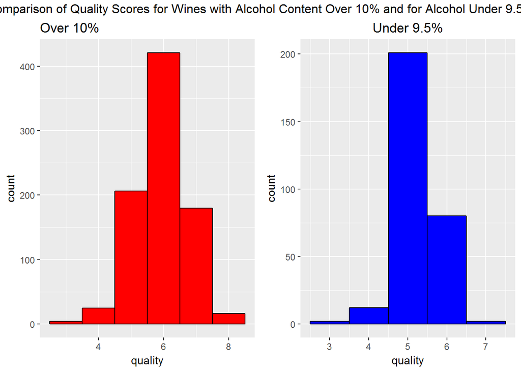

We can see here that the scores look to be higher for the wines with an alcohol content of over 10%.

```
##  [1] "fixed.acidity"        "volatile.acidity"     "citric.acid"
##  [4] "residual.sugar"       "chlorides"            "free.sulfur.dioxide"
##  [7] "total.sulfur.dioxide" "density"              "pH"
## [10] "sulphates"            "alcohol"              "quality"
```

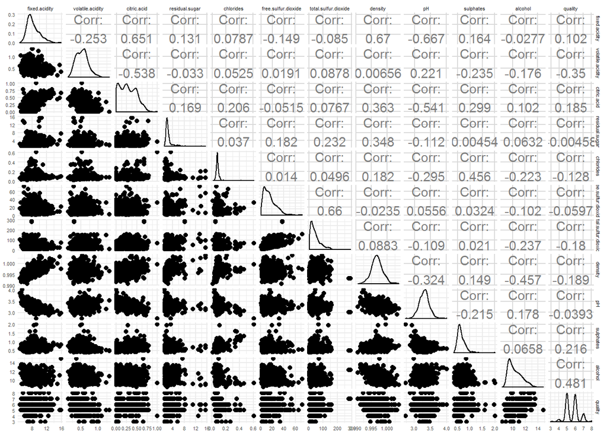

# Univariate Analysis

### What is the structure of your dataset?

Some other things to note about the dataset:

- The median pH of the wines is consistent with the average pH of red wines in general.
- The median amount of residual sugar is around 2.2 g/dm^3, but we have a few wines that are between 12-16 g/dm^3 of residual sugar.
- Almost all of the wines have an alcohol content of between 9% and 13%.

### What is/are the main feature(s) of interest in your dataset?

The main feature of interest in this dataset that I wish to investigate is how all of the 11 continuous variabes impact the one discrete variable (perceived quality of the wine). I am very interested to know whether there is any relationship between individual variables, or combinations of variables, and the perceived quality. If I am not able to find any relationship, it may support the argument that wine quality is more subjective than a sommelier would care to admit. Conversely, if I am able to find a relationship between a variable or combination of variables and quality, we may be able to develop a predicitive model for wine quality scores.

### What other features in the dataset do you think will help support your

### investigation into your feature(s) of interest?

After subsetting the data above and looking at how the first and fourth quartiles of different variables impact quality scores (pH, residual sugar, salt, total sulfur dioxide, free sulfur dioxide, and alcohol), I found that the percentage of alcohol, by volume, the amount of total sulfur dioxide, and the amount of free sulfur dioxide might impact the quality scores of wines. I beleive it will be very interesting to look at the data from a multivariate perspective in that section of this analytical report.

### Did you create any new variables from existing variables in the dataset?

I did not create any new variables from existing variables in the dataset; however, as I go further in the analysis, I will see if the generation of new variables will help my analysis.

### Of the features you investigated, were there any unusual distributions?

### Did you perform any operations on the data to tidy, adjust, or change the form

### of the data? If so, why did you do this?

I did subset the data to look at the impact that certain ranges of values (first and fourth quartiles) might have on perceived wine quality. Probably the most interesting thing I did to the data was perform a scatter matrix on the data to see if there were any interesting relationships in the data that I was missing.

By doing this, I found some expected and not to expected moderate to strong correlation coefficients as follows between the variables:

- Fixed acidity to citric acid: .651 (This is potentially expected since these both measure acids.)
- Volatile aciditiy to citric acid: -.538 (I have no insight into why this relationship might exist. maybe one type of acid can convert into the other?)
- pH to citric acid: -.541 (This seems logical since pH goes down as the amount of acid goes up.)
- Free sulfur dioxide to total sulfur dioxide: .66 (This makes perfect sense since total sulfur dioxide presumably includes free sulfur dioxide.)
- Alcohol to density: -.457 (This makes sense since alcohol is less dense than water, so as alcohol goes up, density should go down and result in a negative correlation.)
- Density to fixed acidity: .67 (I know density here could be a function of alcohol content, with greater density possibly meaning less alcohol and the inverse. Why would there be a relationship between less alcohol (greater density) and more fixed acidity? Does the conversion of components of the wine to alcohol result in the conversion of some acidic components to more basic components? Or maybe the greater the amount of dissolved acids in the water in the wine, the greater the density of the wine [assuming the acids are more dense than water].)
- pH to fixed acidity: -.667 (This seems logical since pH goes down as the amount of acid goes up.)
- Chlorides to sulfates: .456 (I’m not sure why there would be a moderate correlation here.)

Finally, I found there to be a moderately strong correlation (.481) between the quality score and alcohol content in the scatter matrix.

# Bivariate Plots Section

In the bivariate plots section, I wanted to do some further exploration of the relationships that seemed interesting to me in the unvariate section. These relationships included the following:

#### Relationship Between Fixed Acidity and Citric Acid

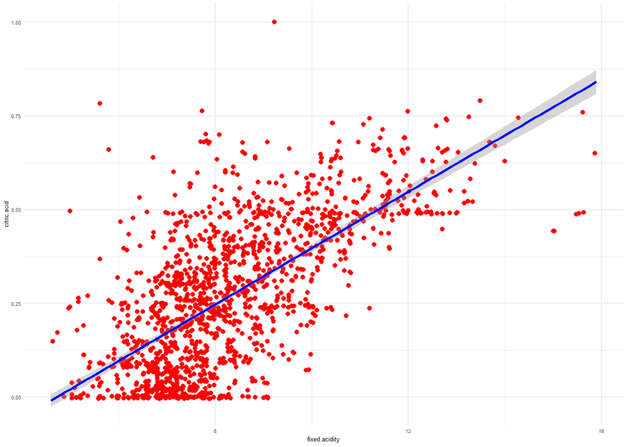

#### Relationship Between Free Sulfur Dioxide and Total Sulfur Dioxide

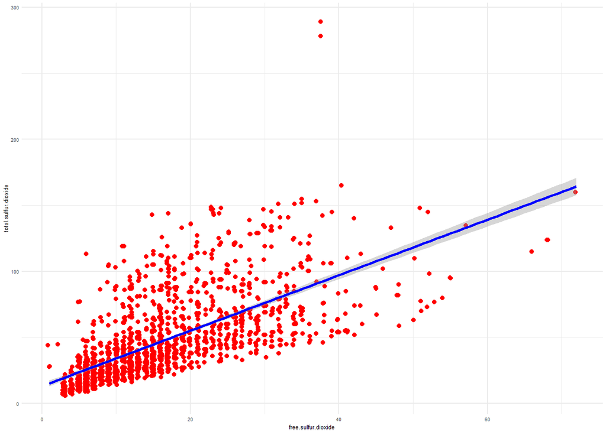

#### Relationship Between Density and Fixed Acidity

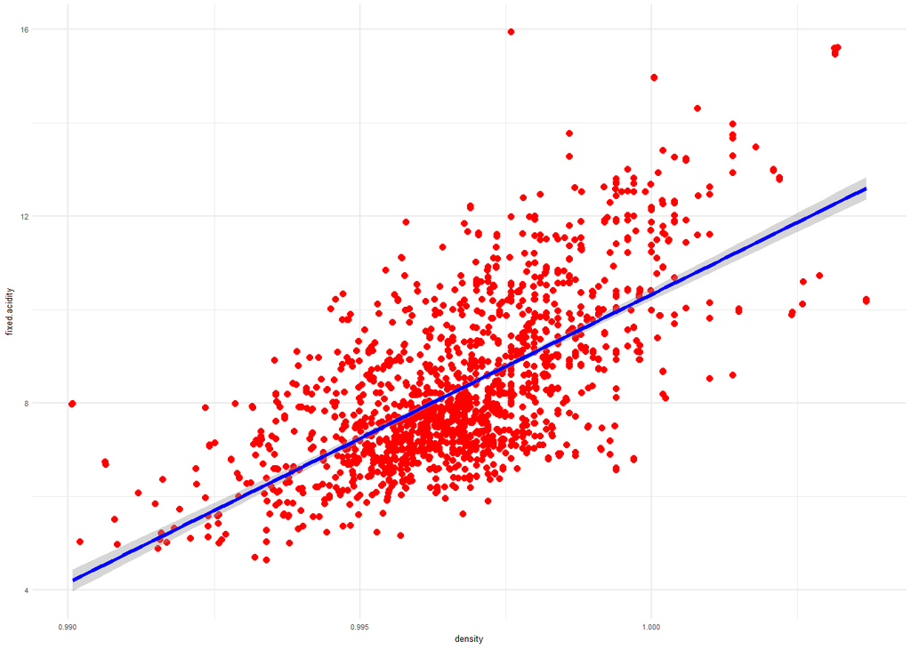

#### Relationship pH and Fixed Acidity

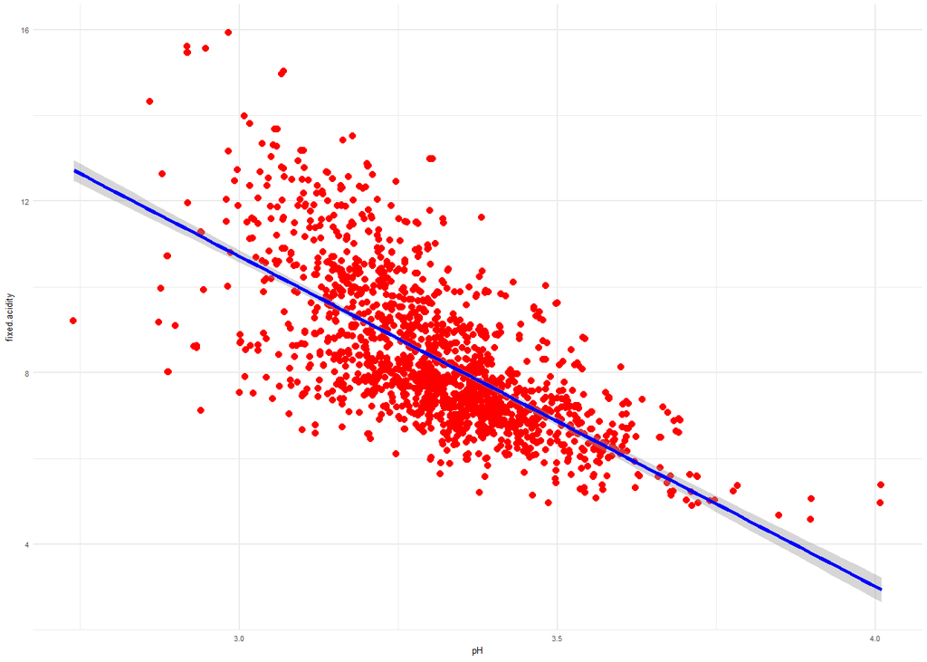

#### Relationship Between Chlorides and Sulfates

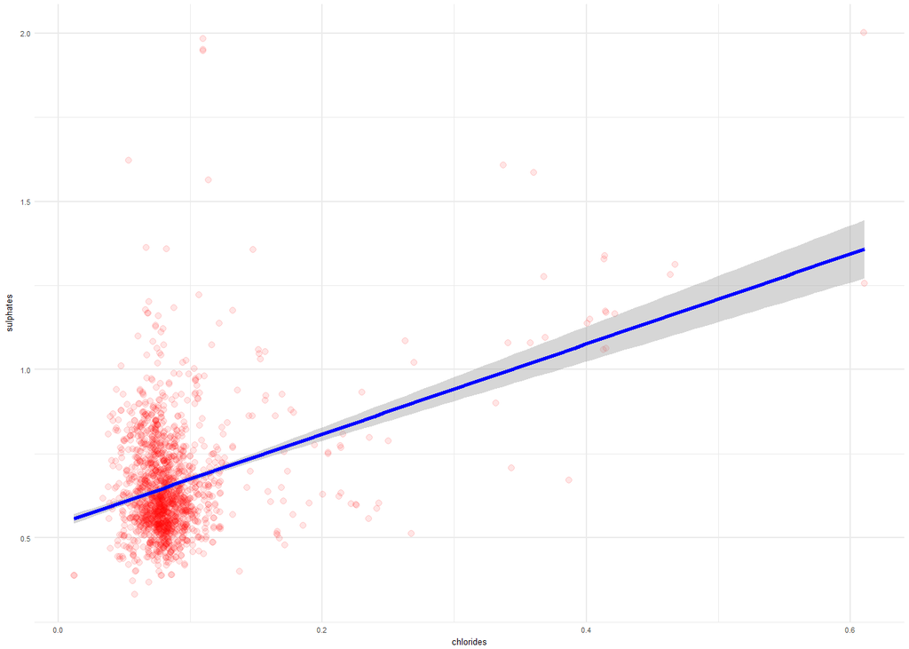

## More Interesting Relationships (To Me)

#### Relationship Between Quality and Total Sulfur Dioxide

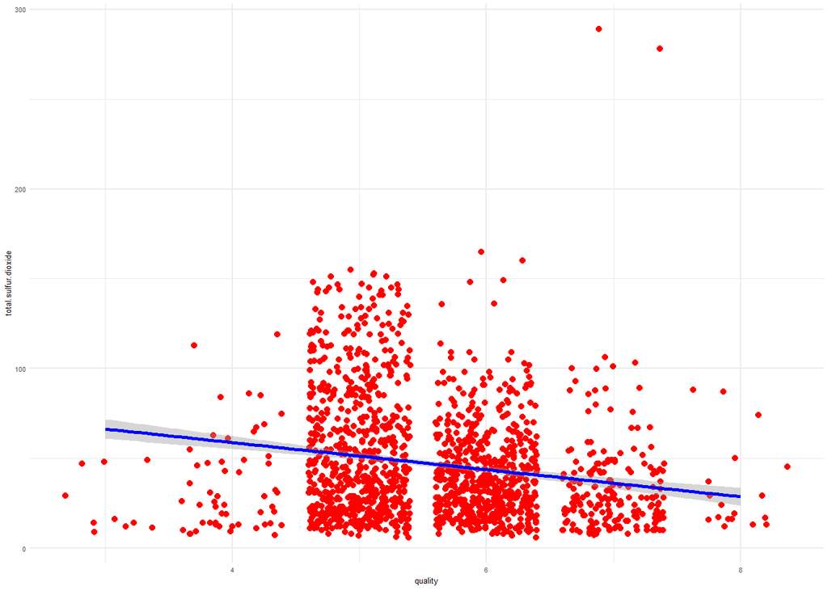

I was very interested here in seeing the mean, median, and interquartile ranges of total sulfur dioxide for each quality rating. There does appear to be an inverse relationship between total sulfur dioxide and quality. It is possible therefore that sulfur is something the wine tasters can taste, and greater amounts of it negativly affects their scores.

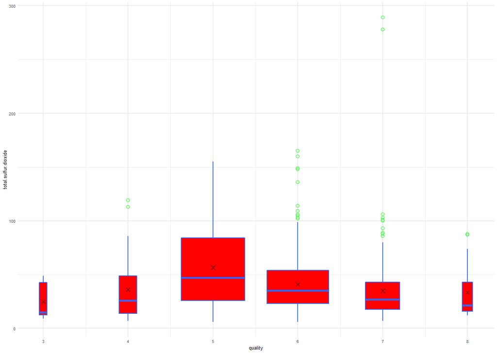

#### Relationship Between Quality and Alcohol Levels

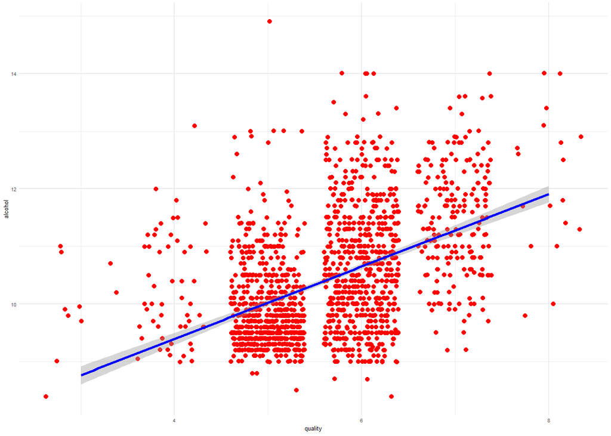

I was very interested here in seeing the mean, median, and interquartile ranges of alcohol for each quality rating. There does appear to be a positive relationship between alcohol and quality rating. It is possible therefore that alcohol is something the wine tasters can taste, and greater amounts of it positively affects their scores.

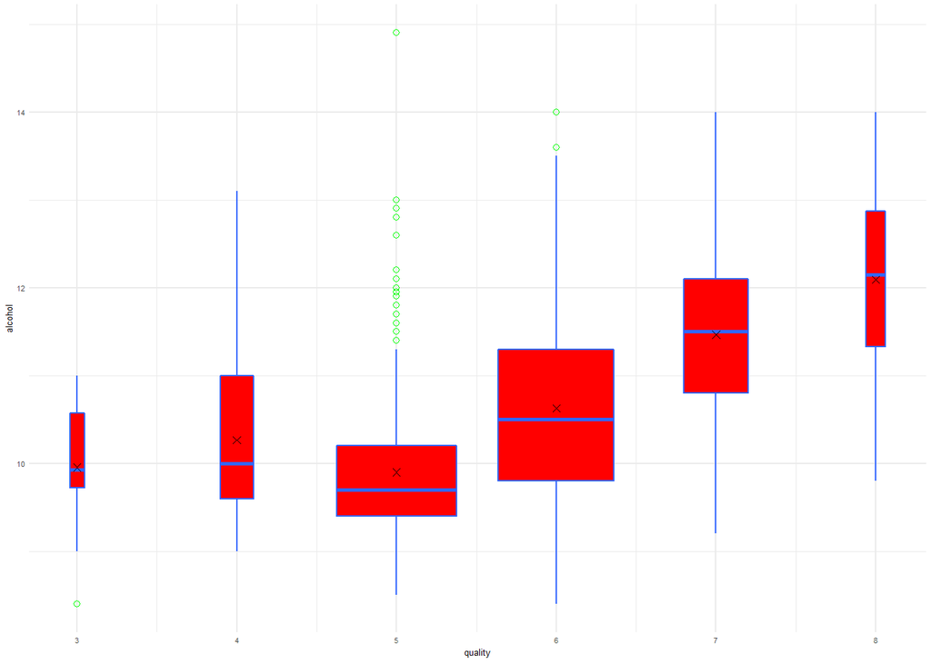

#### Relationship Between Quality and Volatile Acidity

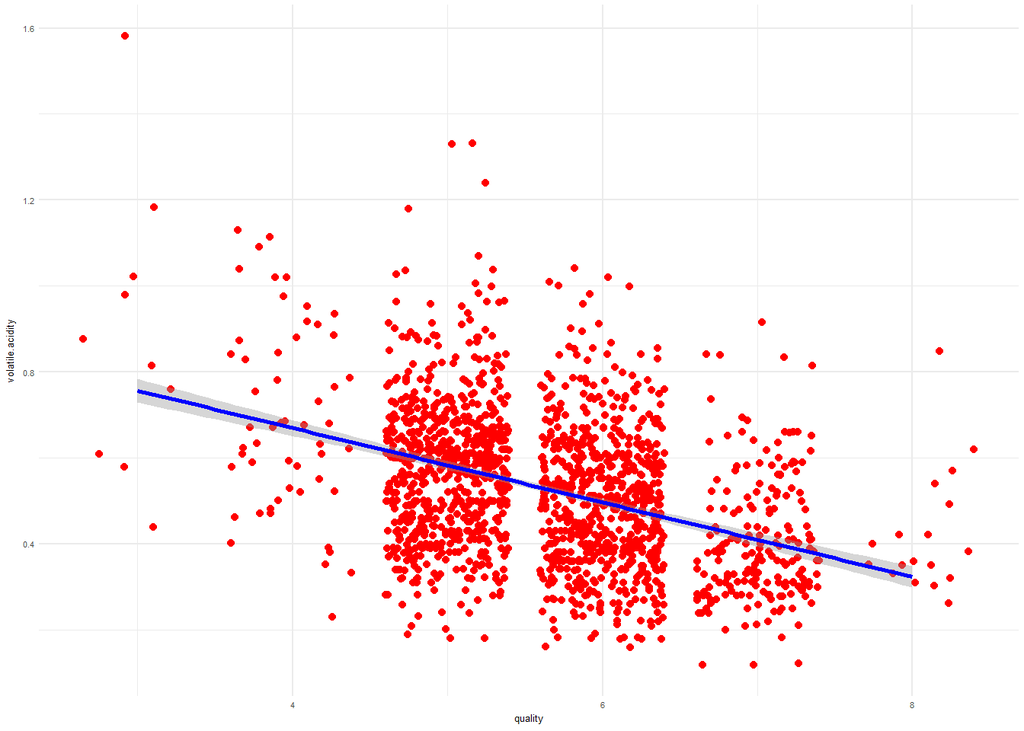

I was very interested here in seeing the mean, median, and interquartile ranges of volatile acidity for each quality rating. There does appear to be an inverse relationship between volatile acidity and quality rating. It is possible therefore that volatile acidity is something the wine tasters can taste, and greater amounts of it negatively affects their scores.

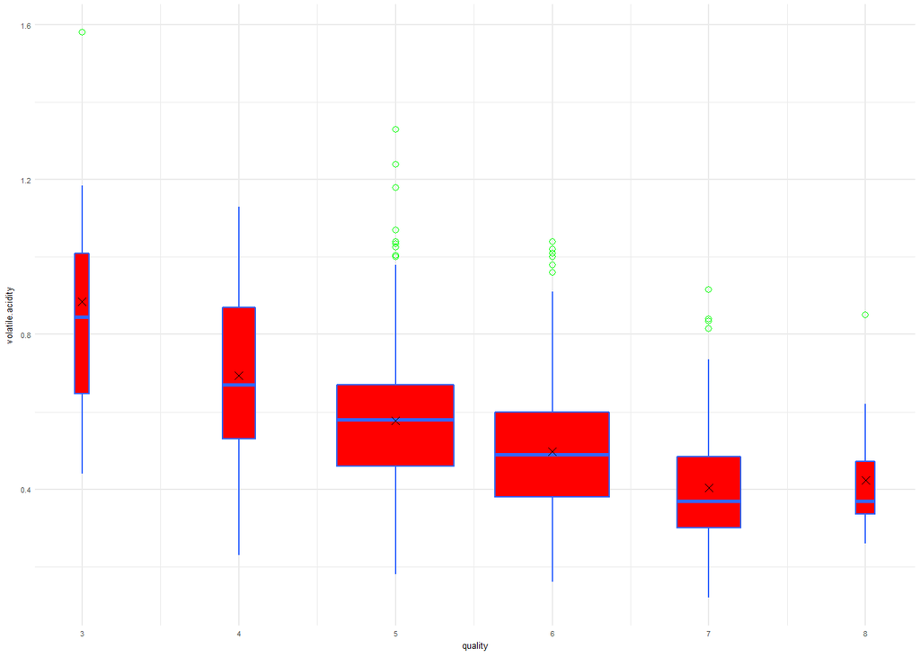

## Failed Attempt at Coding

```
## [1] TRUE
```

```r
# quality_description_data$description <- if (quality_description_data$quality==0) {
#  quality_description_data$description = "Is this even possible?"
# } else if (quality_description_data$quality==1) {
#  quality_description_data$description='Wretched'
# } else if (quality_description_data$quality==2) {
#   quality_description_data$description='Pretty Bad'
# } else if (quality_description_data$quality==3) {
#   quality_description_data$description='Meh'
# } else if (quality_description_data$quality==4) {
#    quality_description_data$description='Drinkable'
# } else if (quality_description_data$quality==5) {
#   quality_description_data$description='Decent Table Wine'
# } else if (quality_description_data$quality==6) {
#   quality_description_data$description='Good Value'
# } else if (quality_description_data$quality==7) {
#   quality_description_data$description='Fancy Restaurant Wine'
# } else if (quality_description_data$quality==8) {
#   quality_description_data$description='Classy Stuff!'
# } else if (quality_description_data$quality==9) {
#   quality_description_data$description='About As Good As It Gets'
# } else if (quality_description_data$quality==10) {
#   quality_description_data$description='Perfection is Impossible'
# } else {quality_description_data$description='No Data'
# }
```

I spent an incredible amount of time (around 3 hours) trying to get the code to work above. I read through forums and Udacity discussion boards. Then I tried to take a different approach below to try to give some description to each of the quality ratings. I know that these are not accurate descriptions of the quality ratings, but I wanted to give them some meaning instead of a number because in the real world, someone looking at this data would want to know what they mean, I think.

I then reproduced the boxplot using those descriptions I developed using the cut() function.

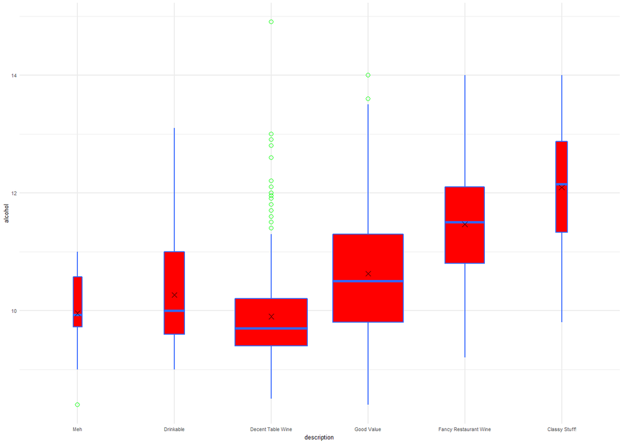

# Bivariate Analysis

### Talk about some of the relationships you observed in this part of the

### investigation. How did the feature(s) of interest vary with other features in

### the dataset?

With the examination of the quality rating being the dependent variable and the other 11 variables being the independent variables, three independent variables are particularly interesting: alcohol levels, total sulfur dioxide, and volatile acidity.

As alcohol increases, quality ratings appear to increase. As total sulfur dioxide increases, quality ratings appear to decrease. As volatile acidity increases, quality ratings appear to decrease.

### Did you observe any interesting relationships between the other features

### (not the main feature(s) of interest)?

Two other interesting relationships were a positive relationship between density and fixed acidity as well as a positive relationship between chlorides and sulfates.

### What was the strongest relationship you found?

In the multivariate plots section I really want to look at the interation between quality, alcohol content, total sulfur dioxide levels, and volatile acidity. In particular, I want to see if the best wines tend to be those with high alcohol content and low total sulfure dioxide and volatile acidity.

# Multivariate Plots Section

First, let’s create categorical variables for all the points of interest so we can plot against them. We have already done this for quality when we created a new variable above, so let’s do this with alcohol content, total sulfur dioxide, and volatile acidity. We will use the min, mean, max and two interquartile values to create the bucket for each variable.

#### Relationship Between Quality, Alcohol, and Total Sulfur Dioxide

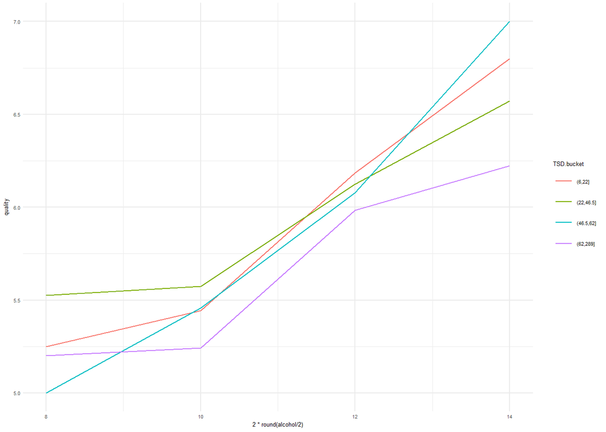

When we look at alcohol content on the x axis versus the quality on the y axis, colored by interquartile ranges of total sulfur dioxide levels, we can see that quality seems to increase as alcohol content increases for all total sulfur dioxide buckets; however, it seems that, in general. the mean quality rating of wine at the same alcohol level tends to be less for those with more total sulfur dioxide (the purple line).

```
##
##   3   4   5   6   7   8
##  10  53 681 638 199  18
```

It would seem it is only worth looking at data for wines with a quality with 5, 6, or 7 here because the same sizes for the other quality levels are so low as to possibly be meaningless.

Also, looking at the next graph, I would say that the graph above would not be relable below an alcohol content of 9% and above 12% because there is a dearth of data below and above these levels.

With the inclusion of only these areas, we can see that wines with high total sulfur content tend to have lower quality scores with alcohol content held constant.

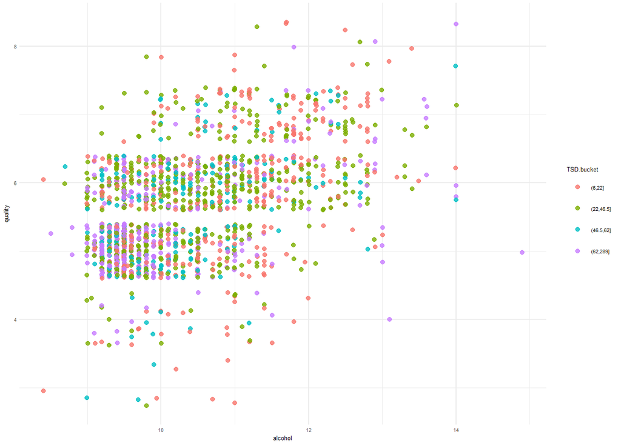

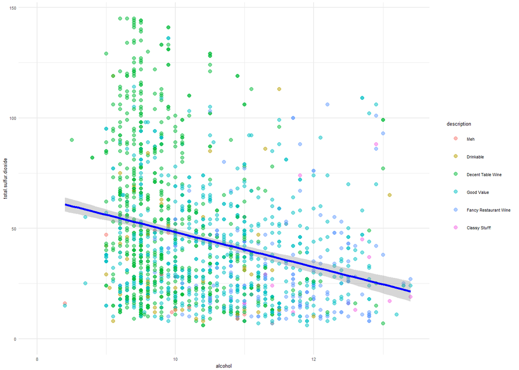

And here, I wanted to look at the data from another perspective. I can see here that as alcohol content increases and total sulfur dioxide decreases, that the quality ratings tend to improve and go from green to teal to blue, with increasing amount of pink as the alcohol increases and total sulfur dioxide decreases.

```
##
##  Pearson's product-moment correlation
##
## data:  quality_description_data$alcohol and quality_description_data$total.sulfur.dioxide
## t = -8.398, df = 1597, p-value < 2.2e-16
## alternative hypothesis: true correlation is not equal to 0
## 99 percent confidence interval:
##  -0.2665121 -0.1431624
## sample estimates:
##        cor
## -0.2056539
```

#### Relationship Between Quality, Alcohol, and Volatile Acidity

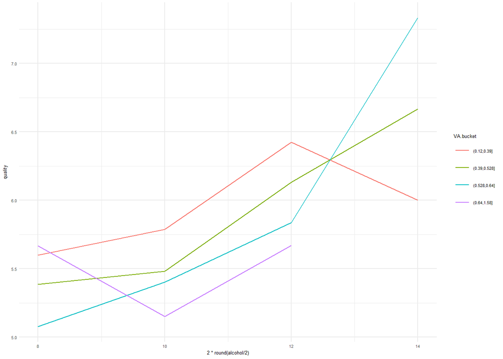

Also, looking at the next graph, I would say that the graph above would not be relable below an alcohol content of 9% and above 12% because there is a dearth of data below and above these levels.

With the inclusion of only these areas, we can see that wines with high volatile acidity tend to have lower quality scores with alcohol content held constant.

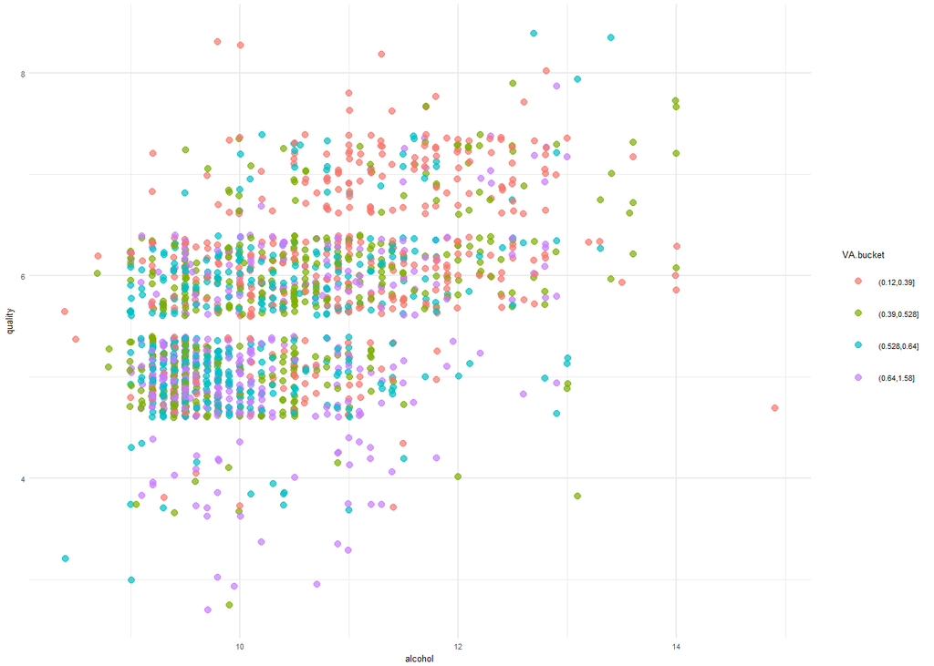

#### Relationship Between Volatile Acidity, Total Sulfur Dioxide, and Quality

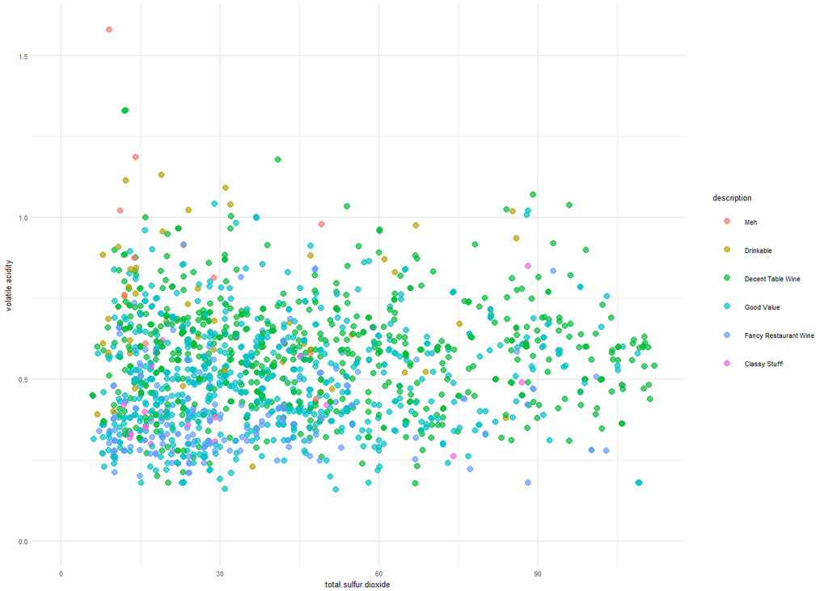

Finally, I wanted to look at total sulfur dioxide versus volatile acidity, colored by quality, to see if there might be a relationship between these variables. If there is a relationship between these variables it might not be the case that there directy impact the dependent variable (quality score) but instead that one affects the other and that in turn affects the dependent variable.

```
##
##  Pearson's product-moment correlation
##
## data:  quality_description_data$volatile.acidity and quality_description_data$total.sulfur.dioxide
## t = 3.0649, df = 1597, p-value = 0.002214
## alternative hypothesis: true correlation is not equal to 0
## 95 percent confidence interval:
##  0.02755215 0.12502248
## sample estimates:
##     cor
## 0.07647
```

Since there does not appear to be a correlation between the three of them, we may be able to say that each of them affects the dependent variable directly (or perhaps that a lurkng variable affects one of these variables which in turn affects the dependent variable.

However it is interesting to note as a confirmation that wines in the lower left of the graph tend to be pink and blue (higher quality score), and then the dots turn teal and green (lower quality score) as we go up and to the right.

#### Relationship Between Volatile Acidity, Total Sulfur Dioxide, and Alcohol

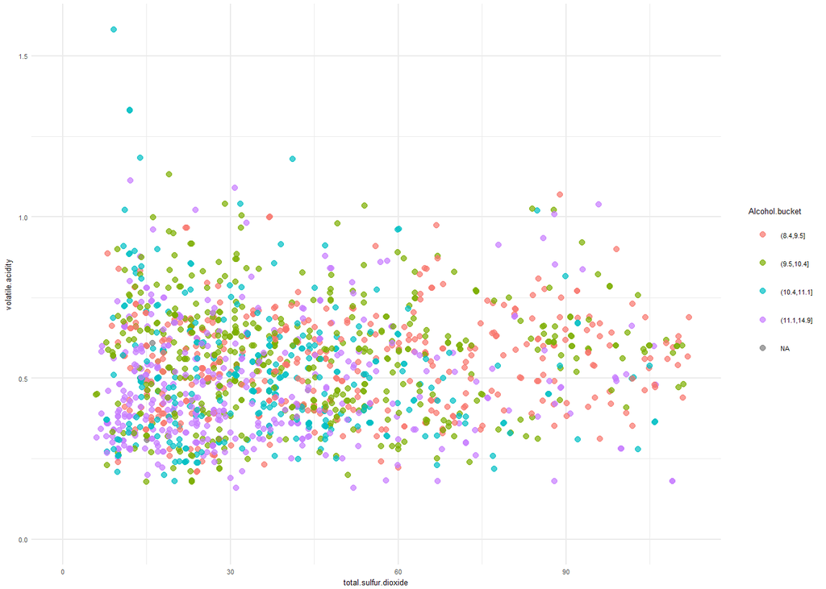

I wanted to see if there was a relationship between total sulfur dioxide, volatile acidity, and alcohol content before doing my final analysis. I wanted to see if there three variables were indepedent of each other in order to know if quality is affected by each of them indvidually or if one has an affect on another that in turn affects quality. These appear to be fairly indepedent to me, and the correlation coefficient above seem to bear that out. There is a very weak inverse correlation between total sulfur dioxide and alcohol and volatile acidity and alcohol (which is why there may be slightly more purple in the bottom left of the graph), but it did not seem interesting enough to probe further.

# Multivariate Analysis

### Talk about some of the relationships you observed in this part of the

### investigation. Were there features that strengthened each other in terms of

### looking at your feature(s) of interest?

It seems that lower total sulfur dioxide, lower volatile acidity, and higher alcohol content tends to increase the quality of wine.

### Were there any interesting or surprising interactions between features?

What seems interesting for further investigation would be to see how alcohol content, total sulfur dioxide, and volatile acidity are correlated, using a larger dataset. I feel like the weak correlation between total sulfur dioxide and alcohol and volatile acidity and alcohol. I’d like to know if these correlations are weakened or strengthened in a larger data set. I want to know this to see if each variable affects quality directly or once variable acts on another and in turn affects quality.

# Final Plots and Summary

### Plot One

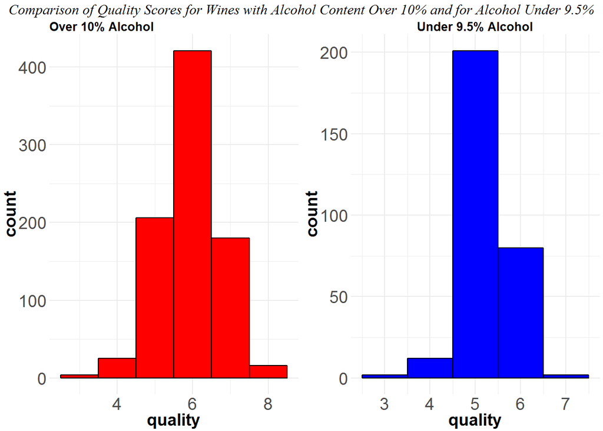

Comparison of Quality Scores for Wines with Alcohol Content Over 10% and for Alcohol Under 9.5%

### Description One

The histogram above shows why alcohol content will be an interesting variable for later exploratoy analysis.

### Plot Two

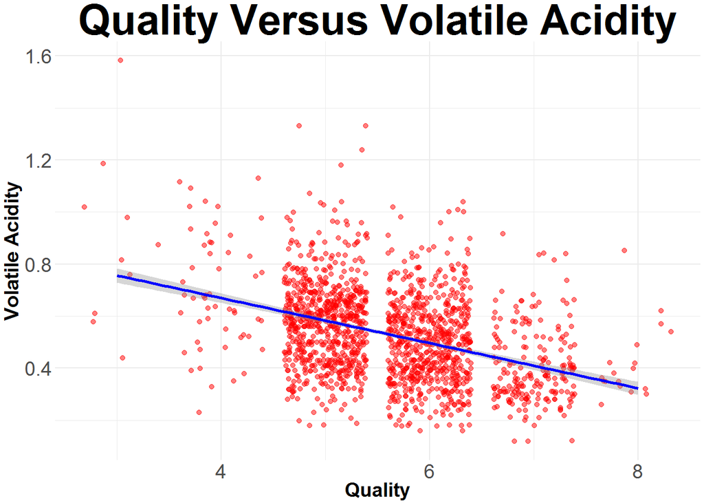

### Description Two

I wanted to show why the relationship between volatile acidity and quality would be an important relationship to measure in the multivariate analysis section.

### Plot Three

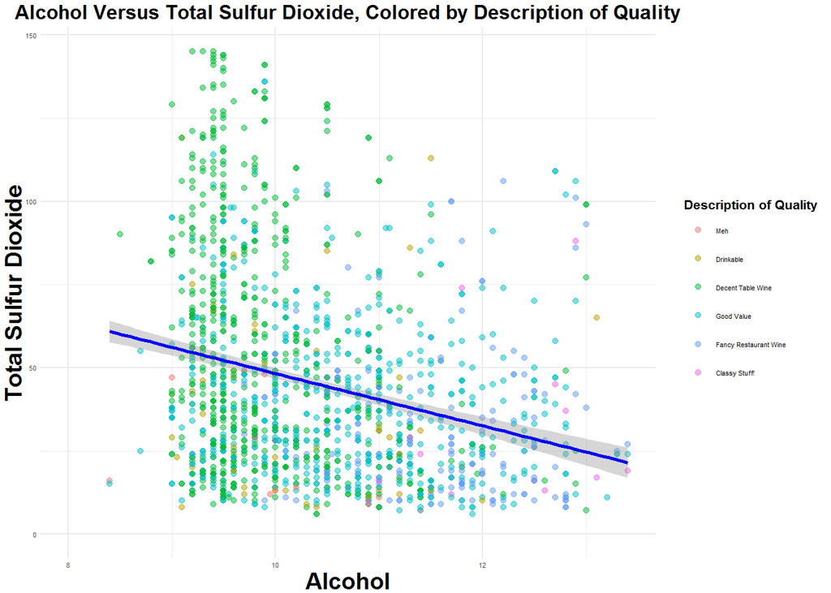

### Description Three

With this plot, I, wanted to show how as alcohol content increased and total sulfur dioxide decreased, we tended to get more wines that were rated with higher quality.

# Reflection

The struggle with exploratory data analysis (and by extension, this exercise) is figuring out which independent variables have explanatory power for the dependant variable and are interesting in that they were not expected to have some explanatory power at the outset.

In this analysis, I found some moderately strong correlations between variables that did not really help understand the dependant variable (quality) in focus. Another struggle was trying to understand whether the variables I think were influencing quality were all influencing indepedently or if there were come confounding variables in the dataset. For example, does alcohol affect quality score directly, or does it affect total sulfur dioxide, which then affects the quality score? Or does volatile acidity affect alcohol content, which in turn affect quality score. In the analysis above, I tried to look for these confounding variables by seeing if there were signifiant correlations between alcohol levels, total sulfur dioxide, and volatily acidity. Since I did not find strong correlations between any two of these, I’m assuming that all three of them may be able to affect the quality score directly in some way.

I think I managed to find three independent variables fairly well that have some explanatory power for quality. I was surpised that the seemingly largest predictor of quality score was alcohol content though.

Since I was not able to find any very strong correlations between quality score and individual variables in the data, it may be that predicting quality a combination of variables simultaneously rather than being significantly explained by one.

I think a larger dataset of wines and a larger number of wine experts tasting each wine is needed to create a robust datset. In such a dataset, a predictive model could be created that could explain a good deal of the variance in quality scores and should possibly include alcohol, total sulfur dioxide, and volatily acidity as predictors (in addition to others) since there were some signs that these three in tandem might help predict quality score.

However, even based on an extremely large dataset, I’m not sure a predictive model would ever be very accurate due to the subjective nature of the quality scores. Such variance in perception and the psychology of the taster is not accounted for in this dataset and thus cannot be included in a predictive model for scores in order to properly refine it.